# act_report

## Report

### A data wrangling project by Iyanujesu Akinyefa

### WeRateDogs Twitter Project Analysis

WeRateDogs is a Twitter account that posts and rates pictures of dogs. These ratings often are not serious and have numerators that are greater than the denominators. In my analysis, I examined WeRateDogs's archive. Most of the necessary Twitter data was provided by Udacity. In addition, Udacity ran the images on WeRateDogs's account through a neural network to generate three predictions for each image. After wrangling the data, I accessed the data, analysed and visualised the data to show insights from the data.

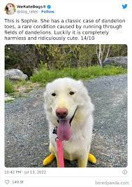

[figure not shown]

### Analysis and Visualisations

In this analysis i analysed top 5 highest average ratings for the predicted dog breeds and the analysis showed the highest average ratings for the dog breeds

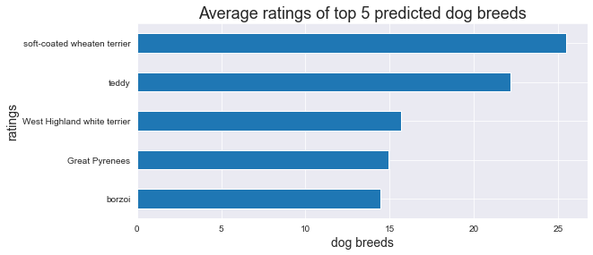

we can see that the soft coated terrier had the highest average rating at 25.5

I also analysed the total number of tweets of the different dog types and we can see that the Pupper type of dog were more in the number and had the highest number of tweets. This shows that people loved pupper type of dogs more than the others

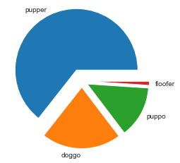

I also used a heatmap to check for correlation between favourite_count, retweet_count and rating numerator

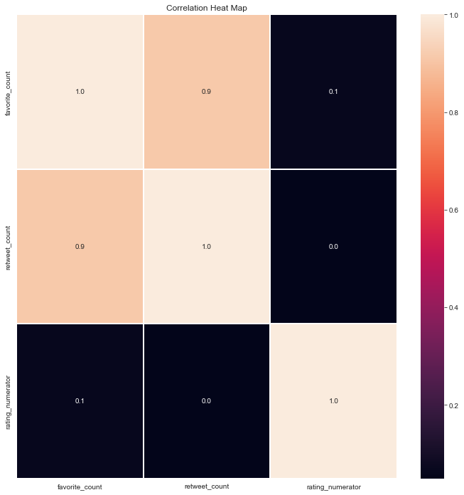

it is seen that there is a Strong correlation between favorite_count and retweet_count and there is No correlation between user ratings and retweet_count and favourite_count